# Say Cheese!

BIOS611 Final Project

### Which countries produce the most cheese varieties?

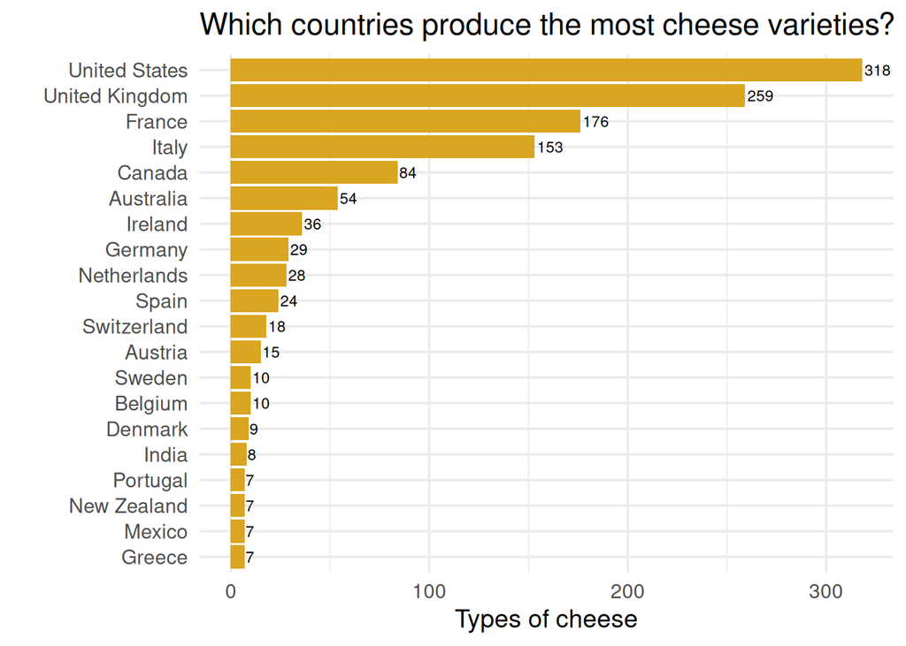

```r
# cheese data
cheeses <- tuesdata$cheeses

# UK is written in many different ways, let's standardize it
country_keywords <- c(
  "United Kingdom" = "United Kingdom",
  "England" = "United Kingdom",
  "Scotland" = "United Kingdom",
  "Wales" = "United Kingdom",
  "Great Britain" = "United Kingdom",
  "Holland" = "Netherlands"
)

## function to clean the country column
clean_country <- function(df, country_col = "country") {
  df %>%
    # Split multi-country entries first
    separate_rows(.data[[country_col]], sep = ",\\s*") %>%
    mutate(country_clean = str_trim(.data[[country_col]])) %>%
    rowwise() %>%
    mutate(
      country_clean = {
        match <- names(country_keywords)[str_detect(country_clean, regex(names(country_keywords), ignore_case = TRUE))]
        if(length(match) > 0) country_keywords[match[1]] else country_clean
      }
    ) %>%
    ungroup() %>%
    filter(!is.na(country_clean))
}

# Apply function
cheeses_clean <- clean_country(cheeses)

# Cheese production across different countries
cheese_counts <- cheeses_clean %>%
  count(country_clean, sort = TRUE) %>%
  filter(!is.na(country_clean)) %>%
  slice_max(n, n = 20)

plot1 <- ggplot(cheese_counts, aes(x = reorder(country_clean, n), y = n)) +
  geom_col(fill = "goldenrod") + #cheesy color
  geom_text(aes(label = n),
            hjust = -0.1,
            size = 3) +
  coord_flip() +
  theme_minimal(base_size = 14) +
  labs(
    x = " ",
    y = "Types of cheese",
    title = "Which countries produce the most cheese varieties?"
  )

#let's check it out!
plot1
```

Interestingly, the United States produces 318 different types of cheeses! The top 5 cheese-producing countries are the United States, the United Kingdom, France, Italy, and Canada.. based on this dataset.

### Which US states produce the most cheese varieties?

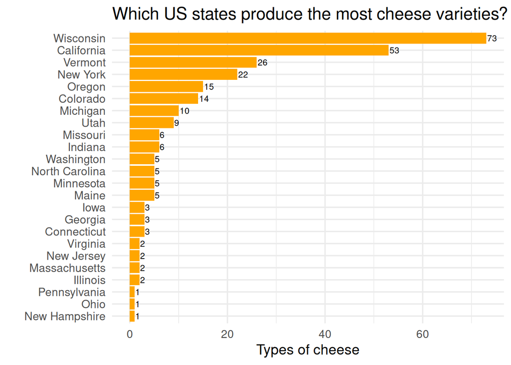

```r
# Let's focus on the US and check out the cheese production by region
cheese_US <- cheeses_clean %>%
  filter(str_detect(country_clean, "United States")) %>%
  filter(!is.na(region)) #we need this info

# US state names and abbreviations
states_full <- state.name
states_abbr <- state.abb
state_lookup <- setNames(state.name, state.abb)

# Cleaning function to fix the region naming
clean_region <- function(region_col) {
  sapply(region_col, function(x) {
    if (is.na(x)) return(NA)

    x_clean <- str_trim(x)

    # 1. Match full state name anywhere in the string
    full_match <- states_full[str_detect(x_clean, regex(states_full, ignore_case = TRUE))]
    if (length(full_match) > 0) return(full_match[1])

    # 2. Match exact state abbreviation (whole word, case-insensitive)
    abb_match <- states_abbr[str_detect(x_clean, regex(paste0("\\b", states_abbr, "\\b"), ignore_case = TRUE))]
    if (length(abb_match) > 0) return(state_lookup[abb_match[1]])

    # 3. If no state match, leave original
    return(x_clean)
  })
}

# Apply to dataset and only include US states as regions
cheesy_states <- cheese_US %>%
  mutate(state = clean_region(region)) %>%
  filter(state %in% state.name)

# Cheese production across different regions in the US, same counting as before
cheese_states_n <- cheesy_states %>%
  count(state, sort = TRUE)

plot2 <- ggplot(cheese_states_n, aes(x = reorder(state, n), y = n)) +
  geom_col(fill = "#FFA600") + #cheddar orange color
  geom_text(aes(label = n),
            hjust = -0.1,
            size = 3) +
  coord_flip() +
  theme_minimal(base_size = 14) +
  labs(
    x = " ",
    y = "Types of cheese",
    title = "Which US states produce the most cheese varieties?"
  )

plot2
```

Wow! Wisconsin produces a LOT of cheese… I am not that surprised though, people from Wisconsin are called cheeseheads for a reason!

### Milk types used in cheese across the world

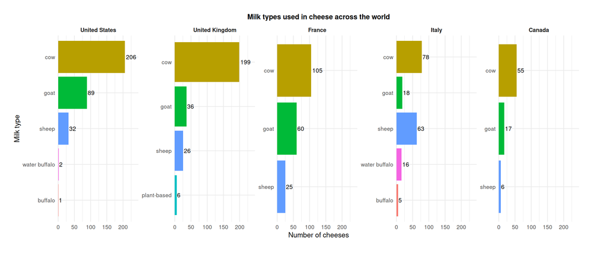

```r
# cleaning milk type column
cheeses_milk_split <- cheeses_clean %>%
  separate_rows(milk, sep = ",\\s*") %>%
  mutate(milk = str_trim(milk)) %>%
  filter(!is.na(milk))

# Getting the top 5 countries by number of cheeses
top_countries <- cheeses_milk_split %>%
  count(country_clean, sort = TRUE) %>%
  slice_max(n, n = 5) %>%
  pull(country_clean)

# Filter and count milk types for only those countries
milk_country_counts <- cheeses_milk_split %>%
  filter(country_clean %in% top_countries) %>%
  count(country_clean, milk, sort = TRUE)

# reorder countries by total cheese count
country_order <- milk_country_counts %>%
  group_by(country_clean) %>%
  summarise(total = sum(n)) %>%
  arrange(desc(total)) %>%
  pull(country_clean)

milk_country_counts <- milk_country_counts %>%
  mutate(country_clean = factor(country_clean, levels = country_order))

# Plot one barplot per country, ordered by total cheese types
plot3 <- ggplot(milk_country_counts, aes(x = reorder(milk, n), y = n, fill = milk)) +
  geom_col(show.legend = FALSE) +
  geom_text(aes(label = n),
            hjust = -0.1,      # slightly outside the bar
            size = 3) +
  facet_wrap(~ country_clean, scales = "free_y", ncol = 5) +
  coord_flip(clip = "off") +       # prevent text from being clipped
  scale_y_continuous(expand = expansion(mult = c(0, 0.2))) +  # add extra space above bars
  labs(
    title = "Milk types used in cheese across the world",
    x = "Milk type",
    y = "Number of cheeses"
  ) +
  theme_minimal(base_size = 10) +
  theme(
    strip.text = element_text(face = "bold"),
    plot.title = element_text(size = 10, face = "bold", hjust = 0.5),
    plot.margin = margin(20, 40, 20, 20)  # top, right, bottom, left
  )

plot3
```

Ok, so cow milk is most commonly used across the top 5 cheese producing countries. Then, goat milk is the second most common in 4 out of the 5 top cheese producing countries (US, UK, France, and Canada). However, Italy has more sheep milk-based cheese than goat! I guess Italians love their sheep cheeses…

### Cheese types across the top 5 cheese-producing countries

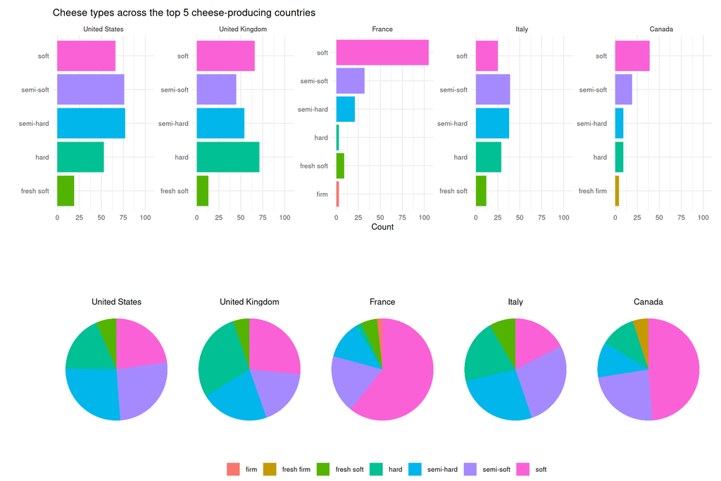

```r
cheeses_clean <- cheeses_clean %>%
  mutate(
    main_type = str_trim(str_split_fixed(type, ",", 2)[,1]) # take first descriptor before comma
  )

cheeses_top <- cheeses_clean %>%
  filter(country_clean %in% top_countries) %>%
  count(country_clean, main_type, sort = TRUE) %>%
  group_by(country_clean) %>%
  slice_max(n, n = 5) %>%     # top 5 types per country
  ungroup() %>% filter(!is.na(main_type))

#fix order
cheeses_top <- cheeses_top %>%
  mutate(country_clean = factor(country_clean, levels = country_order))

# barplot per country
plot_bar <- ggplot(cheeses_top, aes(x = reorder(main_type, n), y = n, fill = main_type)) +
  geom_col(show.legend = FALSE) +
  coord_flip() +
  facet_wrap(~ country_clean, scales = "free_y", ncol = 5) +
  labs(
    title = "Cheese types across the top 5 cheese-producing countries",
    x = "",
    y = "Count"
  ) +
  theme_minimal(base_size = 10)

# let's make it a pie chart for fun!
# Compute proportions per country (so each pie sums to 1)
cheeses_pie <- cheeses_top %>%
  group_by(country_clean) %>%
  mutate(perc = n / sum(n)) %>%
  ungroup()

# Pie chart per country (it's like a cheese wheel haha!)
plot_pie <- ggplot(cheeses_pie %>% filter(perc > 0),
                   aes(x = "", y = perc, fill = main_type)) +
  geom_col(width = 0.95, color = NA) +  # no border lines
  coord_polar(theta = "y") +
  facet_wrap(~ country_clean, ncol = 5) +
  labs(
    title = " ",
    fill = " "
  ) +
  theme_void(base_size = 13) +
  theme(
    strip.text = element_text(size = 10),
    plot.title = element_text(
      hjust = 0.5, size = 16, margin = margin(b = 10, t = 20)
    ),
    legend.position = "bottom",
    legend.direction = "horizontal",
    legend.box = "horizontal",
    legend.title = element_text(size = 10),
    legend.text = element_text(size = 8),
    legend.spacing.x = unit(0.3, "cm")
  ) +
  guides(fill = guide_legend(nrow = 1))

plot4 <- plot_bar / plot_pie

plot4
```

This reveals a very interesting trend. Most of the top 5 cheese producing countries have a good spread of cheese types, but France and Canada both have a large proportion of soft cheeses, it’s actually a majority of the cheeses produced in these countries. I am not surprised by this because France is very famous for its soft cheeses such as Brie and Blue cheese. And many Canadian cheeses are derived from traditional French varieties, reflecting the lasting influence of French colonization in Canada.

### How does fat content vary between soft and hard cheeses?

```r
#let's focus on fat content!
cheeses_fat <- cheeses_clean %>% filter(!is.na(fat_content))

# let's standardize the fat content measurement
cheeses_fat_clean <- cheeses_fat %>%
  mutate(
    fat_percent = case_when(
      # If value is a range like "40-46%"
      str_detect(fat_content, "-") ~ map_dbl(fat_content, function(x) {
        nums <- str_extract_all(x, "\\d+\\.?\\d*")[[1]] %>% as.numeric()
        mean(nums)
      }),
      # If value is a single % like "50%"
      str_detect(fat_content, "%") ~ str_extract(fat_content, "\\d+\\.?\\d*") %>% as.numeric(),
      # If value is g/100g
      str_detect(fat_content, "g/100g") ~ str_extract(fat_content, "\\d+\\.?\\d*") %>% as.numeric(),
      TRUE ~ NA_real_
    )
  )

# Filter to only Soft and Hard cheeses
cheeses_simple <- cheeses_fat_clean %>%
  mutate(
    type_group = case_when(
      str_detect(main_type, "hard") ~ "Hard",
      str_detect(main_type, "soft") ~ "Soft",
      TRUE ~ NA_character_
    )
  ) %>%
  filter(!is.na(type_group))  # remove anything not Soft or Hard

# Performing t test to see if the difference in hard vs. soft cheese is statistically significant
t_test_result <- t.test(fat_percent ~ type_group, data = cheeses_simple)
t_test_result
```

```
##
##  Welch Two Sample t-test
##
## data:  fat_percent by type_group
## t = 2.4401, df = 270.27, p-value = 0.01533
## alternative hypothesis: true difference in means between group Hard and group Soft is not equal to 0
## 95 percent confidence interval:
##  0.7296016 6.8246736
## sample estimates:
## mean in group Hard mean in group Soft
##           39.94045           36.16331
```

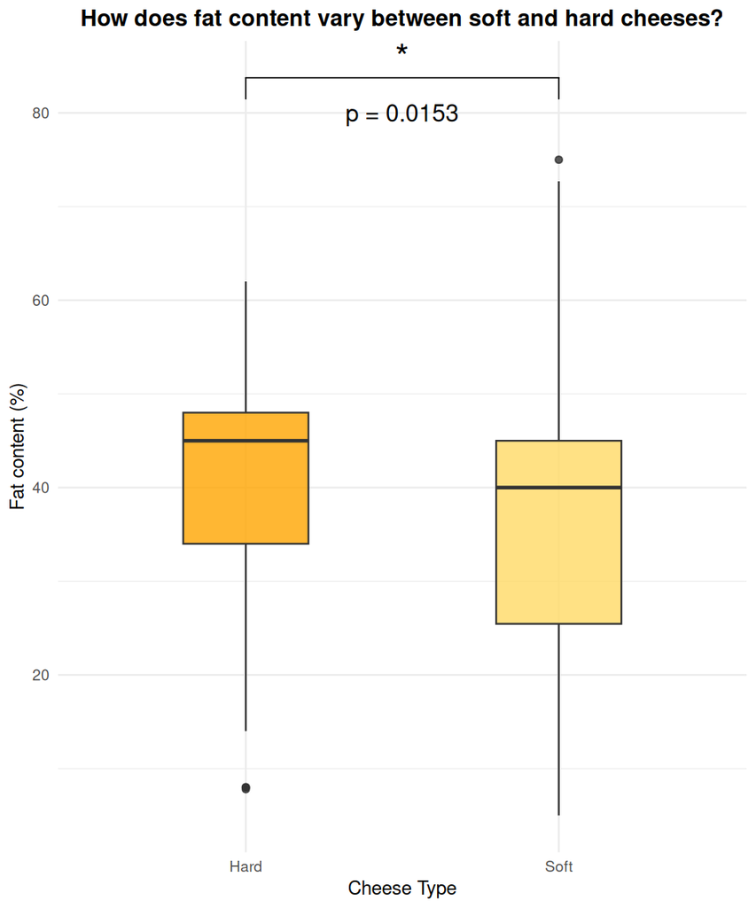

```r
p_val <- t_test_result$p.value  # extract p-value
# Format p-value nicely
p_label <- paste0("p = ", signif(p_val, 3))

# Define cheesy colors for the boxplot
cheese_colors <- c("Soft" = "#FFD966",  # light yellow
                   "Hard" = "#FFA500")  # deeper orange

my_comparisons <- list(c("Soft", "Hard"))

plot5 <- ggplot(cheeses_simple, aes(x = type_group, y = fat_percent, fill = type_group)) +
  geom_boxplot(width = 0.4, alpha = 0.8) +
  scale_fill_manual(values = cheese_colors) +
  labs(
    title = "How does fat content vary between soft and hard cheeses?",
    x = "Cheese Type",
    y = "Fat content (%)",
    fill = "Cheese Type"
  ) +
  theme_minimal(base_size = 9) +
  theme(
    legend.position = "none",
    plot.title = element_text(hjust = 0.5, face = "bold")
  ) +
  stat_compare_means(
    comparisons = my_comparisons,
    method = "t.test",
    label = "p.signif",      # shows *, **, ***
    tip.length = 0.03,       # length of the horizontal ends of the bracket
    size = 6,                # size of the asterisk
    label.y = max(cheeses_simple$fat_percent) + 5
  ) +
  annotate(
    "text",
    x = 1.5,  # middle between the two boxes (Soft = 1, Hard = 2)
    y = max(cheeses_simple$fat_percent) + 5,  # position above boxes
    label = p_label,
    size = 4
  )

plot5
```

Well, this is interesting! I performed a t-test to compare fat content between hard and soft cheeses, and the p-value = 0.01533. Since p < 0.05, we can say that the difference in fat content between hard and soft cheeses is statistically significant. Clearly, the hard cheeses have higher fat content compared to soft cheeses, which makes sense because the longer aging and lower moisture in hard cheeses concentrate fat.

### How does average fat content vary between cheese families?

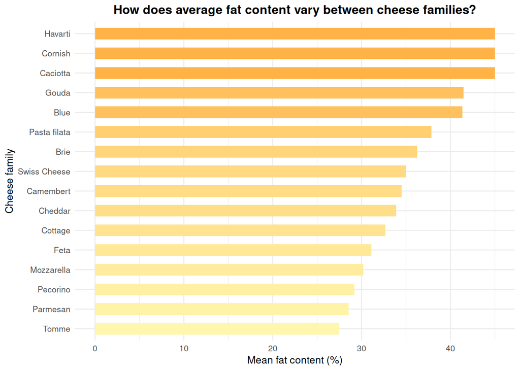

```r
# let's look at fat content across different cheese families
cheese_family_fat <- cheeses_simple %>%
  filter(!is.na(fat_percent), !is.na(family)) %>%
  group_by(family) %>%
  summarize(mean_fat = mean(fat_percent, na.rm = TRUE)) %>%
  arrange(desc(mean_fat))


plot6 <- ggplot(cheese_family_fat, aes(x = reorder(family, mean_fat), y = mean_fat, fill = mean_fat)) +
  geom_col(width = 0.6) +
  coord_flip() +  # makes it easier to read long family names
  scale_fill_gradient(low = "#FFF7AE", high = "#FFB347") +
  labs(
    title = "How does average fat content vary between cheese families?",
    x = "Cheese family",
    y = "Mean fat content (%)"
  ) +
  theme_minimal(base_size = 10) +
  theme(
    legend.position = "none",
    plot.title = element_text(hjust = 0.5, face = "bold")
  )

plot6
```

Based on this barplot, we can see that Havarti, Cornish, and Caciotta families have the highest fat content! And I think they are extra yummy… now that are are done with our cheesy adventure, you deserve a treat! How about a grilled cheese? :)